# State of the Union Analysis

## Analysis of USA's State of the Union Addresses

This exercise attempts to better understand speech patterns of USA's SOTU addresses across time thorough natural language processing and unsupervised learning techniques (such as TF-IDF, PCA, and K-means clustering).

```python
import json
import numpy as np
import matplotlib.pyplot as plt
import nltk
import statistics as stat
import pandas as pd
import string
import re
from gensim.models import TfidfModel
from gensim import corpora
import matplotlib.pyplot as plt
from nltk import tokenize
from nltk.tokenize import sent_tokenize, word_tokenize
```

```python
"""
Let us first process the downloaded data.
Data Processing
"""
with open('speeches.json', 'r') as f:
    speeches = json.loads(f.read())

#Separate the speeches into sentences and tokenize the words.
for i in range(len(speeches)):
    speeches[i]['sentence'] = sent_tokenize(speeches[i]['text'])
    for sentence_i in range(len(speeches[i]['sentence'])):
        speeches[i]['sentence'][sentence_i] =
        speeches[i]['sentence'][sentence_i].rstrip("\n\r")
    #Create template of dimension (#sentences)
    speeches[i]['word'] = np.empty([len(speeches[i]['sentence'])])
    for j in range(len(speeches[i]['sentence'])):
        #Find number of words
        speeches[i]['word'][j]=len(word_tokenize(speeches[i]
                                                 ['sentence'][j]))

#Create list of attributes by year, to understand how the number of
#sentences and average length of speeches have changed over the years.
which_year_list = np.empty(226)
num_sentences_list = np.empty(226)
average_length_list = np.empty(226)
for yr in range(226):
    num_sentences_list[yr] = len(speeches[yr]['sentence'])
    average_length_list[yr] = stat.mean(speeches[yr]['word'])
    which_year_list[yr] = speeches[yr]['year']
```

```python
def clean_and_split(s):
    """
    Input: uncleaned text
    Output: cleaned text covered to bag of words
    """
    #covert to lower case, translate to white space
    s = s.lower().replace('-',' ').translate(s.maketrans(" ",
    " ",string.punctuation))
    # replace \r\n
    s = re.sub('(\r\n)+',' ',s)
    # replace whitespace substrings with one whitespace and remove
    # leading/trailing whitespaces
    s = re.sub(' +',' ',s.strip())
    return s.split(' ')

cleaned_text = [clean_and_split(speeches[i]['text']) for i in range(226)]

#Obtain dictionary / list of unique words
dictionaryA = corpora.Dictionary(cleaned_text)
```

```python
import itertools
from operator import itemgetter

#Merge all speeches into 1 giant text. This is to calculate
#Which are the most and least common words across all eras
merged_texts = list(itertools.chain(*cleaned_text))

#Find count, "overall" is list with length of unique words,
#containing tuple of word ID, and word count
overall = dictionaryA.doc2bow(merged_texts)

"""
Filter the dictionary to reduce vocabulary size
"""
#obtain ID of top 20 common words
common_words = [words[0] for words in sorted(overall,
                key=itemgetter(1),reverse=True)[:20]]
#Obtain ID of words with <50 frequency
uncommon_words = [word[0] for word in overall if word[1] < 50]
dictionaryA.filter_tokens(bad_ids = common_words + uncommon_words)

corpus_list = [dictionaryA.doc2bow(speech) for speech in cleaned_text]
```

```python
#Use package to find Tf-idf values
TFIDF = TfidfModel(corpus_list)

#We want to transform it into a Matrix where
#Row i = document i, column j = jth word in dictionary
def transform_TFIDF(document):
    row_d = np.zeros(len(dictionaryA))
    for i in range(len(dictionaryA)):
        if i in [word[0] for word in document]:
            row_d[i]=[word[1] for word in document if word[0] == i][0]
        else:
            row_d[i]=0
    return(row_d)

TFIDF_mat = np.zeros((226, len(dictionaryA)))
for i in range(len(speeches)):
    TFIDF_mat[i] = transform_TFIDF(TFIDF[corpus_list[i]])

print("We work with this TFIDF matrix of shape ",
      TFIDF_mat.shape)
```

```
We work with this TFIDF matrix of shape  (226, 3228)
```

From the above, the following steps are taken:

1. Clean and split the words in all speeches
2. Obtain dictionary of unique words
3. Merge all text into 1 giant text. From here, determine the top 20 words and less common words to be removed. Filter to reduce vocabulary size.
4. Find Tf-idf values
5. Change Tf-idf into a matrix

### Similarity

Next, we determine which speeches are more similar to others via a similarity function, which calculate the similarity of 2 speeches based on the inner products of their TF-IDF matrices.

```python
def similarity(A_doc, B_doc):
    numerator = np.inner(TFIDF_mat[A_doc], TFIDF_mat[B_doc])
    denom = np.linalg.norm(TFIDF_mat[A_doc])*
            np.linalg.norm(TFIDF_mat[B_doc])
    return(numerator/denom)

dataframe = []
for i in range(226):
    for j in range(i+1,226):
        dataframe.append((speeches[i]['president'],
                          speeches[j]['president'],
                          speeches[i]['year'],speeches[j]['year'],
                            similarity(i,j)))
dataframe1 = pd.DataFrame(dataframe)
dataframe1.columns = ["P1", "P2", "i", "j", "similar"]

diffdf = dataframe1[dataframe1.P1 != dataframe1.P2]
samedf = dataframe1[dataframe1.P1 == dataframe1.P2]
dataframe2 = diffdf.groupby(["P1", "P2"]).agg({"similar": "mean"})

#Find 50 most similar, by different presidents
different = diffdf.sort_values("similar",ascending=False)[:50]
#Find 50 most similar, by same presidents
samee = samedf.sort_values("similar",ascending=False)[:50]
#Find 25 most similar presidents
presidents = dataframe2.sort_values("similar",ascending=False)[:25]
```

```python
#Find the most similar speeches but from different presidents

print("50 similar pairs, different presidents: ", different)
```

```
50 similar pairs, different presidents:                          P1                   P2     i     j   similar
25268   William J. Clinton         Barack Obama  1995  2010  0.664777
25269   William J. Clinton         Barack Obama  1995  2011  0.640592
25270   William J. Clinton         Barack Obama  1995  2012  0.633873
10720           John Tyler        James K. Polk  1844  1846  0.621938
16913     Grover Cleveland    Benjamin Harrison  1885  1889  0.607520
25196          George Bush   William J. Clinton  1992  1995  0.605375
25230   William J. Clinton         Barack Obama  1993  2009  0.598301
25250   William J. Clinton         Barack Obama  1994  2010  0.593710
9317        Andrew Jackson     Martin Van Buren  1836  1839  0.589453
15841  Rutherford B. Hayes     Grover Cleveland  1877  1885  0.585564
16249  Rutherford B. Hayes     Grover Cleveland  1880  1885  0.584977
25195          George Bush   William J. Clinton  1992  1994  0.584080
25317   William J. Clinton         Barack Obama  1998  2011  0.581065
10719           John Tyler        James K. Polk  1844  1845  0.577064
```

[output cut: 36 more lines]

```python
#Find the most similar speeches from the same president

print("50 similar pairs, similar presidents: ", samee)
```

```
50 similar pairs, similar presidents:                           P1                    P2     i     j   similar
25404        George W. Bush        George W. Bush  2007  2008  0.806011
25424          Barack Obama          Barack Obama  2012  2013  0.792306
25420          Barack Obama          Barack Obama  2010  2012  0.778512
25419          Barack Obama          Barack Obama  2010  2011  0.768951
25422          Barack Obama          Barack Obama  2011  2012  0.754807
25289    William J. Clinton    William J. Clinton  1997  1998  0.748509
25305    William J. Clinton    William J. Clinton  1998  1999  0.741649
24249     Lyndon B. Johnson     Lyndon B. Johnson  1966  1967  0.734551
25306    William J. Clinton    William J. Clinton  1998  2000  0.723068
25290    William J. Clinton    William J. Clinton  1997  1999  0.718908
25415          Barack Obama          Barack Obama  2009  2010  0.710873
25391        George W. Bush        George W. Bush  2005  2008  0.707982
25320    William J. Clinton    William J. Clinton  1999  2000  0.707845
18639      William McKinley      William McKinley  1899  1900  0.706412
```

[output cut: 36 more lines]

```python
print("25 similar presidents: ", presidents)
```

```
25 similar presidents:                                             similar
P1                   P2
William J. Clinton   Barack Obama         0.521541
Zachary Taylor       Millard Fillmore     0.500041
George Bush          William J. Clinton   0.486842
                     Barack Obama         0.476449
Ronald Reagan        George Bush          0.469710
Rutherford B. Hayes  Chester A. Arthur    0.452786
Ronald Reagan        William J. Clinton   0.442608
James K. Polk        Millard Fillmore     0.438237
Andrew Jackson       Martin Van Buren     0.432294
Theodore Roosevelt   William Howard Taft  0.430477
Chester A. Arthur    Grover Cleveland     0.428540
                     Benjamin Harrison    0.427783
Ronald Reagan        Barack Obama         0.424120
Chester A. Arthur    William Howard Taft  0.423875
Millard Fillmore     Franklin Pierce      0.417701
Martin Van Buren     John Tyler           0.417290
James K. Polk        Zachary Taylor       0.416943
Rutherford B. Hayes  Grover Cleveland     0.415237
Benjamin Harrison    Grover Cleveland     0.415125
Dwight D. Eisenhower John F. Kennedy      0.409630
Zachary Taylor       Franklin Pierce      0.406273
Grover Cleveland     Benjamin Harrison    0.405367
John Tyler           James K. Polk        0.402796
Franklin Pierce      James Buchanan       0.400629
Rutherford B. Hayes  Benjamin Harrison    0.399823
```

Manual reading of the speeches seem to agree with the scores above.

We observe that similarity of speeches can be predicted/are related by either:

1. Sequence in time (i.e. speeches closer in date are more similar). For example, Barack Obama's speeches are more similar to Bill Clinton or George Bush than to Lincoln. Likewise, a speech in the 1800s will be more similar to another speech in the 1800s than 2000s. This is due to linguistic differences. Over time, the English language / word choice will change, preferences for certain style will evolve, and this is reflected in the similarities as well. Likewise, the focus in politics shift over time. For example, speeches in 1800s may talk about independence and slavery, while that in 2000s talk about the war on terror.
2. Party. For example, Obama's speeches are more similar to Bill Clinton's, rather than George Bush, a different party president. This can be explained by the party focus - i.e. Obama and Clinton may focus on different policy issues as democrats compared to the Republicans.

To understand how can we construct a better similarity measure, we first need to understand what are we trying to measure in terms of saying that 2 documents are similar - are they similar in subject matter, or in linguistic style? Our method seems to focus on the 2nd one.

1. The packages we employ (e.g. gensim) are biased towards (i.e. more able to recognize) today's words than those in the 1800s and early 1900s due to usage and word style. Hence, a better similarity measure will not be too dependent on the dictionary.
2. Length of speech affects similarity. The length of speech increases with year. Hence, this implies that the dictionary may be more influenced by words from recent years than in the past. A way to improve this is to ensure the length of all speeches are the same - perhaps by selecting a subset from each speech such that the length is normalized.
3. Whether the speech is written or spoken may affect similarity too. Speeches spoken may be more similar due to the spoken style, compared to written documents, which can take a larger variation. The only way to address this is to compare written or spoken speeches separately.

The above points also cover ways to construct a better similarity matrix. Other ways may include taking into consideration the sequences of words (i.e. word embeddings) instead of a bag-of-words model, since a same word may mean different things in 2 eras.

### Principal Component Analysis

To visualize the speeches, we will employ PCA (components = 2) to reduce the speeches into 2-dimensional space.

```python
"""
Use available PCA package in sklearn
"""

from sklearn.cluster import KMeans
from sklearn.preprocessing import StandardScaler
from sklearn.decomposition import PCA

#First, let us proceed with PCA
#Purpose is to visualize the data in 2 dimensions.
scaled = StandardScaler().fit_transform(TFIDF_mat)
pca_data = PCA(n_components=2).fit_transform(scaled)
```

```
K =  2
Clusters: [0 0 0 0 0 0 0 0 0 0 0 0 0 0 0 0 0 0 0 0 0 0 0 0 0 0 0 0 0 0 0 0 0 0 0 0 0
 0 0 0 0 0 0 0 0 0 0 0 0 0 0 0 0 0 0 0 0 0 0 0 0 0 0 0 0 0 0 0 0 0 0 0 0 0
 0 0 0 0 0 0 0 0 0 0 0 0 0 0 0 0 0 0 0 0 0 0 0 0 0 0 0 0 0 0 0 0 0 0 0 0 0
 0 0 0 0 0 0 0 0 0 0 0 0 0 0 0 0 0 0 0 0 0 0 0 0 0 0 0 0 0 0 0 0 1 1 1 1 1
 1 1 1 1 1 1 1 1 1 1 1 1 1 1 1 1 1 1 1 1 1 1 1 1 1 1 1 1 1 1 1 1 1 1 1 1 1
 1 1 1 1 1 1 1 1 1 1 1 1 1 1 1 1 1 1 1 1 1 1 1 1 1 1 1 1 1 1 1 1 1 1 1 1 1
 1 1 1 1]
```

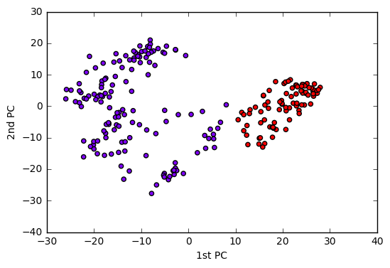

```
K =  5
Clusters: [0 0 0 0 0 0 0 0 0 0 0 0 0 0 0 0 0 0 0 0 0 0 0 0 0 0 0 0 0 0 0 0 0 0 0 0 0
 0 0 0 0 0 0 0 0 0 0 0 0 0 0 0 0 0 0 0 0 0 0 0 0 0 0 0 0 0 0 0 0 0 0 0 3 3
 3 0 0 3 3 3 3 3 3 3 3 3 3 3 3 3 3 3 3 3 3 3 3 4 3 3 3 3 3 3 3 3 3 3 3 3 3
 4 4 4 4 4 4 4 4 4 4 4 4 4 4 4 4 4 4 4 4 4 4 4 4 4 4 4 4 4 4 4 4 1 1 1 1 1
 1 1 1 1 1 1 1 1 1 1 1 1 1 1 1 1 1 1 1 1 1 1 1 1 1 1 1 1 1 2 2 2 2 1 1 1 1
 2 1 2 1 2 2 2 2 1 2 2 2 2 2 2 2 2 2 2 2 2 2 2 2 2 2 2 2 2 2 2 2 2 2 2 2 2
 2 2 2 2]
```

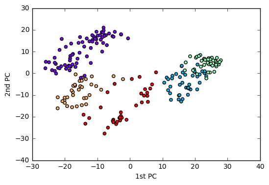

```
K =  8
Clusters: [0 0 0 0 0 0 0 0 0 0 0 0 0 0 0 0 0 0 0 0 0 0 0 0 0 0 0 0 0 0 0 0 0 0 0 0 0
 0 0 0 0 0 0 0 0 0 7 7 7 7 7 7 7 7 7 7 7 7 7 7 7 7 7 7 7 7 7 7 7 7 7 7 7 7
 7 7 7 7 3 7 7 7 7 7 7 7 7 3 3 3 3 3 3 3 3 3 3 6 3 3 3 3 3 3 3 3 3 3 7 5 5
 5 5 5 5 5 5 5 5 6 6 6 6 5 5 5 5 5 5 5 5 5 5 6 6 6 6 6 6 6 6 6 6 2 2 2 2 2
 2 2 2 4 4 2 2 2 2 2 2 2 2 2 2 2 2 2 2 2 2 2 2 2 2 2 4 4 4 4 4 4 4 4 4 4 4
 4 4 4 4 1 1 1 1 2 1 1 1 1 1 1 1 1 1 1 1 1 1 1 1 1 1 1 1 1 1 1 1 1 1 1 1 1
 1 1 1 1]
```

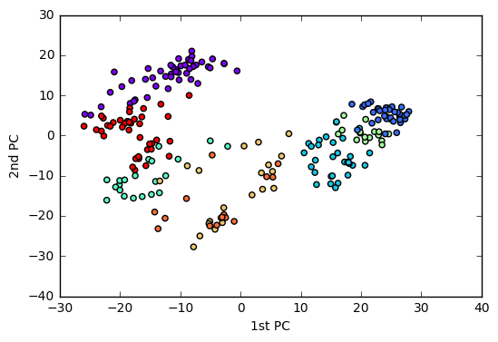

```
K =  10
Clusters: [3 3 3 3 3 7 7 7 7 7 7 9 3 9 9 9 9 9 9 9 3 9 9 3 3 3 3 3 3 3 3 3 3 3 3 3 3
 3 3 3 1 3 3 3 3 1 1 1 1 1 1 1 1 1 1 1 1 1 1 1 1 1 1 1 1 1 1 1 1 1 1 4 4 1
 4 1 4 4 4 4 4 4 4 4 4 4 4 4 4 4 4 4 4 4 4 4 4 4 4 4 4 4 4 4 4 4 4 4 4 6 6
 6 6 6 6 6 6 6 6 6 6 6 6 6 6 6 6 8 5 5 6 5 5 5 5 5 5 5 5 5 5 5 5 8 8 8 8 8
 8 8 8 8 8 8 8 8 8 8 8 8 8 8 8 8 8 8 8 8 8 8 8 8 8 8 8 2 2 2 2 2 2 2 2 2 2
 2 2 2 2 2 2 2 2 8 2 2 2 2 2 2 2 2 2 2 2 2 2 2 2 2 2 2 2 2 0 0 0 0 0 0 0 2
 2 2 2 2]
```

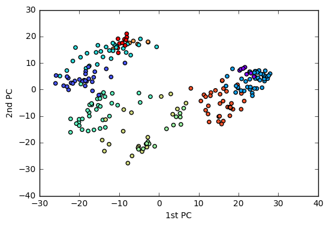

```
K =  25
Clusters: [ 0  7  7  7  7  7  7 19 19 19 19  0  0  8 13 13 13 13 13 14 14 14 14 14
 14  7  7  8  8  8  8  8  8  8  8 16 16 16 16  7  7  7  7  7  7  7  2  7
  7  2  7  2  2 11 11 11 11 11 11 11 11 11 11  7 11 11 11 22 22 22 22 11
 22  9  9  2 11  2  2  3  3  3  9  3  9  3  9  9  9  9  9  9  9  9  9  9
  9  9  9  9  9 23 23 23 23 23 23 23 20 20 20  4  4  4  4  4  4  4  4  4
  4  4  4  4  4  4  4 15  4  4  4  4  4 24 24 24 24 24 24 24 10  4 10  6
 10  6  6  6  6  6  6 15 15 15 15 10 10  6  6  6 21 21 21 10 10 10 10 10
 21 10  6 10 10 10 17  1 17 17 17 17 17 17 18 18 18 18 18 18 18 18 18 21
 18 10 18 18  1  1  1  1  1  5  5 18  5  5  5  5  5  5  5  5  5  5 12 12
 12 12 12 12 12  5  5  5  5  5]
```

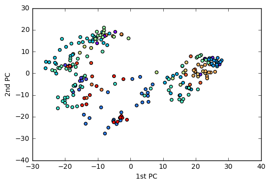

```python
#K-Means is performed in original dimension
def display_cluster(k):
    model = KMeans(n_clusters= k)
    sou_clust = model.fit(TFIDF_mat)
    clustering = sou_clust.predict(TFIDF_mat)

    print("K = ", k)
    print("Clusters:", clustering)
    plt.scatter(pca_data[:,0], pca_data[:,1],
                c=clustering,cmap="rainbow")
    plt.ylabel('2nd PC')
    plt.xlabel('1st PC')
    plt.show()

#Displace clusters for different values of k
display_cluster(2)
display_cluster(5)
display_cluster(8)
display_cluster(10)
display_cluster(25)
```

From the clustering results, we observe they are related to the years too - speeches by the same president, and/or are close in years, belong to the same clusters. This agrees with what we've observed in terms of the similarity measure from above.

However, can we interpret each principal component? To do this, we plot some possible variables with the 1st and 2nd PC, such as year, and average sentence length.

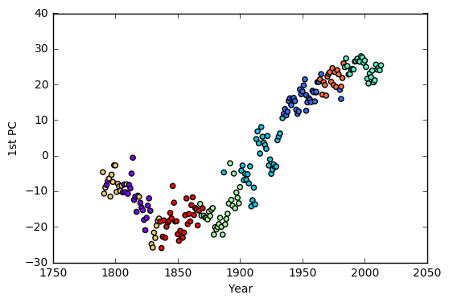

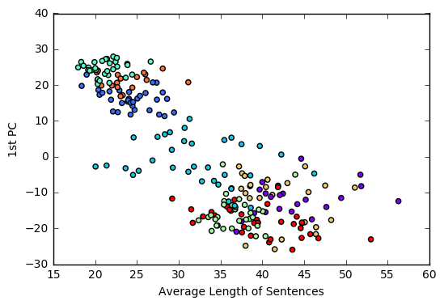

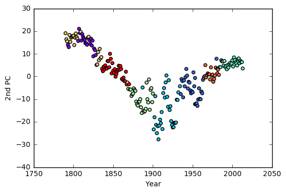

```python
#Can each PC be interpreted?
#Let k = 8
model = KMeans(n_clusters= 8)
sou_clust = model.fit(TFIDF_mat)
clustering_final = sou_clust.predict(TFIDF_mat)

plt.scatter(which_year_list , pca_data[:,0],
            c=clustering_final,cmap="rainbow")
plt.ylabel('1st PC')
plt.xlabel('Year')
plt.show()

plt.scatter(average_length_list  , pca_data[:,0],
            c=clustering_final,cmap="rainbow")
plt.ylabel('1st PC')
plt.xlabel('Average Length of Sentences')
plt.show()

plt.scatter(which_year_list, pca_data[:,1],
            c=clustering_final,cmap="rainbow")
plt.ylabel('2nd PC')
plt.xlabel('Year')
plt.show()
```

Observe that there is definitely a trend between the 1st/2nd PC, with year, although this trend is not directly linear - there is a change in gradient at 1850s (for 1st PC) and 1910 (2nd PC). However, the 1st PC is inversely proportional to average sentence length.

From the plots above, we also noticed that the clusters (here k=8) are generally also clustered based on years/time. Hence, the results are interpretable.